# Predictive Modeling Techniques in Big Data Analytics: Advanced Regression and Prediction

### Visualizations for the Best Approach

According to our validation set, the best approach is **Weigthed Ensemble**, which has the following predictions:

- **Scatted Plot**, predicted vs. actual:

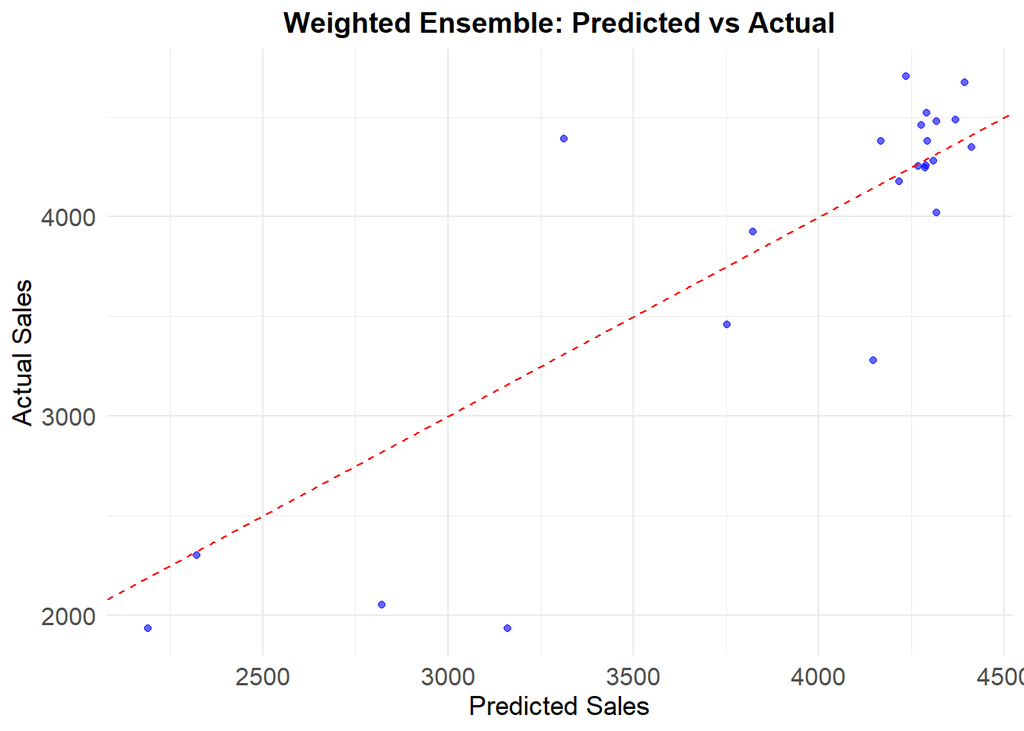

```r
# Plot predicted vs actual values for Stacking Ensemble
ggplot(val_cv, aes(x = ensemble_data$ensemble_weighted, y = Sales)) +
  geom_point(color = "blue", alpha = 0.6) +
  geom_abline(slope = 1, intercept = 0, color = "red", linetype = "dashed") +
  labs(
    title = "Weighted Ensemble: Predicted vs Actual",
    x = "Predicted Sales",
    y = "Actual Sales"
  ) +
  theme_minimal() +
  theme(
    plot.title = element_text(hjust = 0.5, size = 14, face = "bold"),
    axis.text = element_text(size = 12),
    axis.title = element_text(size = 13)
  )
```

- **Time Series Plot**, predicted vs. actual:

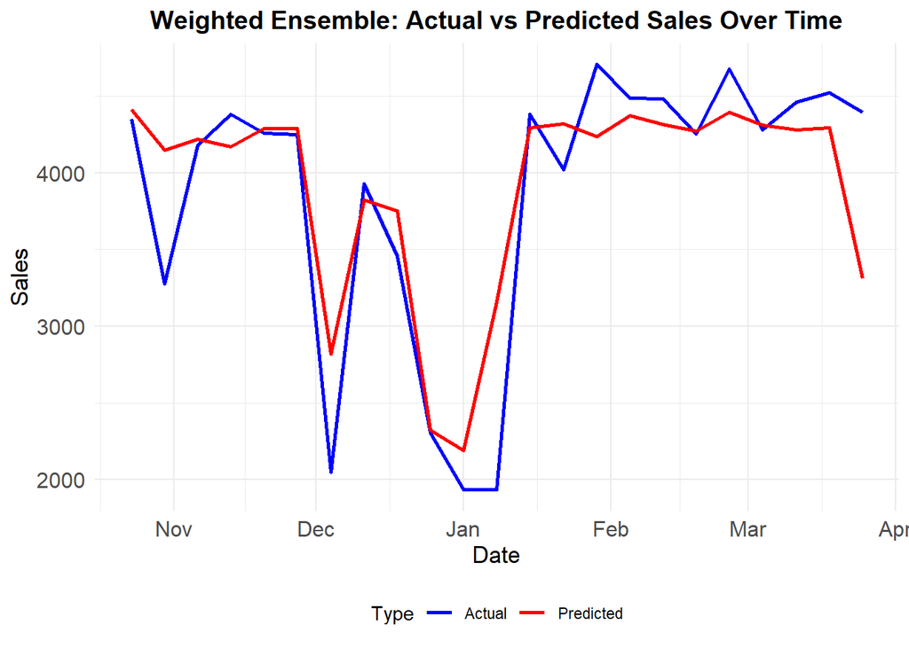

```r
# Create time series plot of actual vs predicted sales
ggplot(val_cv, aes(x = Monday_date)) +
  geom_line(aes(y = Sales, color = "Actual"), linewidth = 1) +
  geom_line(aes(y = ensemble_data$ensemble_weighted, color = "Predicted"), linewidth = 1) +
  scale_color_manual(values = c("Actual" = "blue", "Predicted" = "red")) +
  labs(
    title = "Weighted Ensemble: Actual vs Predicted Sales Over Time",
    x = "Date",
    y = "Sales",
    color = "Type"
  ) +
  theme_minimal() +
  theme(
    plot.title = element_text(hjust = 0.5, size = 14, face = "bold"),
    axis.text = element_text(size = 12),
    axis.title = element_text(size = 13),
    legend.position = "bottom"
  )
```

We notice the Weigthed Ensembles captures most of the trends in the validation dataset.

## Model Comparison

To evaluate the performance of the models and optimization strategies implemented, the following table summarizes the **Mean Absolute Error (MAE) for each best-performing model** across all approaches:

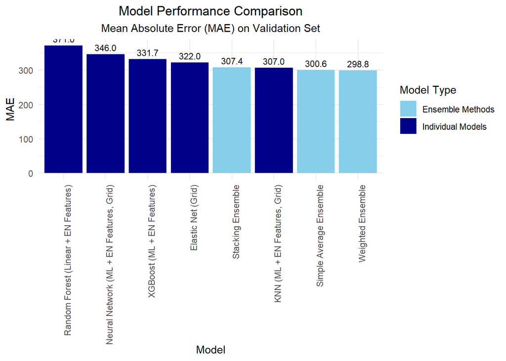

```r
# Create dataframe with model performance
model_performance <- data.frame(
  Model = c(
    "Elastic Net (Grid)",
    "Random Forest (Linear + EN Features)",
    "XGBoost (ML + EN Features)",
    "KNN (ML + EN Features, Grid)",
    "Neural Network (ML + EN Features, Grid)",
    "Simple Average Ensemble",
    "Weighted Ensemble",
    "Stacking Ensemble"
  ),
  MAE = c(
    mean(abs(val_cv$elastic_grid_pred - val_cv$Sales)),
    mean(abs(val_cv$rf_linear_en_features_pred - val_cv$Sales)),
    mean(abs(val_cv$xgb_en_features_pred - val_cv$Sales)),
    mean(abs(val_cv$knn_en_features_grid_pred - val_cv$Sales)),
    mean(abs(val_cv$nnet_grid_pred - val_cv$Sales)),
    mae_avg,
    mae_weighted,
    mae_stacking
  )
) %>%
  arrange(MAE)  # Sort by MAE

# Calculate improvement over baseline (Elastic Net)
model_performance <- model_performance %>%
  mutate(
    Improvement = (max(MAE) - MAE) / max(MAE) * 100,
    Category = case_when(
      grepl("Ensemble", Model) ~ "Ensemble Methods",
      TRUE ~ "Individual Models"
    )
  )

# Create comparison plot
ggplot(model_performance, aes(x = reorder(Model, -MAE), y = MAE, fill = Category)) +
  geom_bar(stat = "identity") +
  geom_text(aes(label = sprintf("%.1f", MAE)),
            vjust = -0.5, size = 3) +
  scale_fill_manual(values = c("Ensemble Methods" = "skyblue",
                              "Individual Models" = "darkblue")) +
  labs(
    title = "Model Performance Comparison",
    subtitle = "Mean Absolute Error (MAE) on Validation Set",
    x = "Model",
    y = "MAE",
    fill = "Model Type"
  ) +
  theme_minimal() +
  theme(
    axis.text.x = element_text(angle = 90, hjust = 1),
    plot.title = element_text(hjust = 0.5),
    plot.subtitle = element_text(hjust = 0.5)
  )
```

```r
# Print performance table
print("Model Performance Summary:")
```

```
## [1] "Model Performance Summary:"
```

```r
print(model_performance)
```

```
##                                     Model      MAE Improvement
## 1                       Weighted Ensemble 298.7548   19.468947
## 2                 Simple Average Ensemble 300.6478   18.958671
## 3            KNN (ML + EN Features, Grid) 306.9710   17.254223
## 4                       Stacking Ensemble 307.3553   17.150625
## 5                      Elastic Net (Grid) 321.9590   13.214138
## 6              XGBoost (ML + EN Features) 331.7412   10.577276
## 7 Neural Network (ML + EN Features, Grid) 346.0074    6.731737
## 8    Random Forest (Linear + EN Features) 370.9809    0.000000
##            Category
## 1  Ensemble Methods
## 2  Ensemble Methods
## 3 Individual Models
## 4  Ensemble Methods
## 5 Individual Models
## 6 Individual Models
## 7 Individual Models
## 8 Individual Models
```

The **Weighted Ensemble** model achieved the lowest MAE of **299**, outperforming all individual models and optimization techniques.

# Final Model and Predictions

To **get the final predictions**, we will:

- Retrain the selected models on the **full training dataset** (merging `train_cv` and `val_cv`).
- Repeat **hyperparameter tuning** with the most successful configuration in each case (but using more data now).
- Compute the **new individual MAEs** that will act as weights for the Weighted Ensemble model.

```r
# Get common columns between train_cv and val_cv
common_cols <- intersect(colnames(train_cv), colnames(val_cv))

# Combine training and validation datasets using only common columns
full_train <- rbind(
  train_cv[, common_cols],
  val_cv[, common_cols]
)

# Define new time series cross-validation control for full training data
n_iter_cv_full <- 3  # Number of CV iterations
full_train_weeks <- nrow(full_train)
initial_window_full <- floor(0.5 * full_train_weeks)  # 50% of data for initial training
assessment_size_full <- floor((full_train_weeks - initial_window_full) / n_iter_cv_full)

ctrl_full <- trainControl(
  method = "timeslice",
  initialWindow = initial_window_full,
  horizon = assessment_size_full,
  skip = assessment_size_full - 1,
  fixedWindow = TRUE,
  allowParallel = TRUE,
  verboseIter = TRUE
)

# 1. Retrain Elastic Net with grid search
elastic_grid_final <- train(
  formula_linear,
  data = full_train,
  method = "glmnet",
  tuneGrid = expand.grid(
    alpha = seq(0, 1, by = 0.1),
    lambda = seq(0, 0.1, by = 0.01)
  ),
  metric = "MAE",
  trControl = ctrl_full
)

# 2. Retrain Random Forest with linear formula and elastic net features
rf_grid_final <- train(
  formula_linear_elastic_grid,
  data = full_train,
  method = "rf",
  tuneGrid = expand.grid(mtry = c(2, 4, 6, 8)),
  metric = "MAE",
  trControl = ctrl_full,
  ntree = 500
)

# 3. Retrain XGBoost with grid search
xgb_grid_final <- train(
  formula_ml_elastic_grid,
  data = full_train,
  method = "xgbTree",
  tuneGrid = expand.grid(
    nrounds = c(100, 200),
    max_depth = c(3, 6),
    eta = c(0.01, 0.1),
    gamma = c(0, 1, 5),
    colsample_bytree = c(0.6, 0.8, 1),
    min_child_weight = c(1, 5),
    subsample = c(0.7, 1)
  ),
  metric = "MAE",
  trControl = ctrl_full,
  verbose = FALSE,
  verbosity = 0
)

# 4. Retrain KNN with grid search
knn_grid_final <- train(
  formula_ml_elastic_grid,
  data = full_train,
  method = "knn",
  tuneGrid = data.frame(k = seq(1, 20, by = 2)),
  metric = "MAE",
  trControl = ctrl_full,
  preProcess = c("center", "scale")
)

# 5. Retrain Neural Network with grid search
nnet_grid_final <- train(
  formula_ml_elastic_grid,
  data = full_train,
  method = "nnet",
  linout = TRUE,
  tuneGrid = expand.grid(
    size = c(5, 10, 15),
    decay = c(0.001, 0.01, 0.1)
  ),
  metric = "MAE",
  trace = FALSE,
  trControl = ctrl_full,
  preProcess = c("center", "scale")
)
```

The **best hyperparameters** found by re-doing hyperparameter tuning with all data are:

```r
# Print best parameters for each model
cat("\nBest parameters for each model:\n")
```

```
##
## Best parameters for each model:
```

```r
cat("\nElastic Net:\n")
```

```
##
## Elastic Net:
```

```r
print(elastic_grid_final$bestTune)
```

```
##    alpha lambda
## 17   0.1   0.05
```

```r
cat("\nRandom Forest:\n")
```

```
##
## Random Forest:
```

```r
print(rf_grid_final$bestTune)
```

```
##   mtry
## 4    8
```

```r
cat("\nXGBoost:\n")
```

```
##
## XGBoost:
```

```r
print(xgb_grid_final$bestTune)
```

```
##     nrounds max_depth eta gamma colsample_bytree min_child_weight subsample
## 181     100         3 0.1     1              0.8                5       0.7
```

```r
cat("\nKNN:\n")
```

```
##
## KNN:
```

```r
print(knn_grid_final$bestTune)
```

```
##   k
## 1 1
```

```r
cat("\nNeural Network:\n")
```

```
##
## Neural Network:
```

```r
print(nnet_grid_final$bestTune)
```

```
##   size decay
## 3    5   0.1
```

Note they **generally do not match** the hyperparmeters found using `train_cv` only.

The **cross-validation MAEs** are given by the following code snippet. For models using log transformation (elastic net and random forest), we need to transform MAE back to original scale. If MAE is the average of |log(pred) - log(true)|, then exp(MAE) approximates the ratio pred/true; so exp(MAE)-1 approximates the relative error |pred-true|/true and multiplying by mean(true) gives us the MAE in original scale.

```r
# Calculate final cross-validation MAEs for each model
mean_sales <- mean(full_train$Sales)
cv_maes <- c(
  (exp(min(elastic_grid_final$results$MAE)) - 1) * mean_sales,  # Transform from log scale
  (exp(min(rf_grid_final$results$MAE)) - 1) * mean_sales,       # Transform from log scale
  min(xgb_grid_final$results$MAE),                              # Already in original scale
  min(knn_grid_final$results$MAE),                              # Already in original scale
  min(nnet_grid_final$results$MAE)                              # Already in original scale
)

# Print cross-validation MAEs
print("\nCross-validation MAEs:")
```

```
## [1] "\nCross-validation MAEs:"
```

```r
names(cv_maes) <- c("Elastic Net", "Random Forest", "XGBoost", "KNN", "Neural Network")
print(cv_maes)
```

```
##    Elastic Net  Random Forest        XGBoost            KNN Neural Network
##       318.7759       391.5681       237.0022       296.0877       285.4576
```

When re-training with the whole training data, **the best model is now XGBoost**, followed by other Machine Learning models (KNN and Neural Networks). Elastic Net and Random Forest have fallen all the way to the last spot.

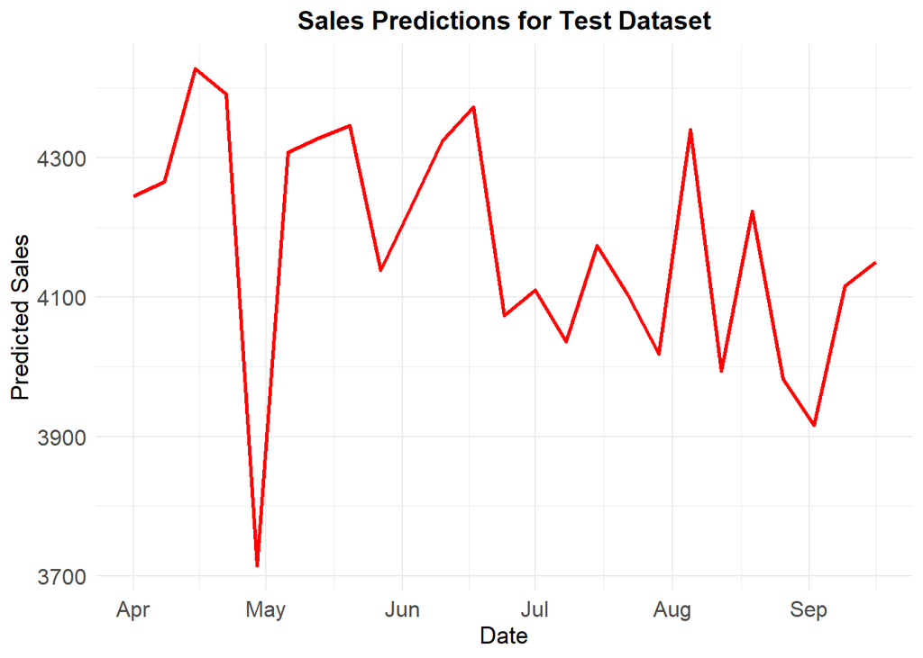

```r
# Generate predictions for test dataset
test_pred <- data.frame(
  elastic = exp(predict(elastic_grid_final, test_sales_data)) - 1,
  rf = exp(predict(rf_grid_final, test_sales_data)) - 1,
  xgb = predict(xgb_grid_final, test_sales_data),
  knn = predict(knn_grid_final, test_sales_data),
  nnet = predict(nnet_grid_final, test_sales_data)
)

# Calculate weights based on cross-validation MAE
weights <- 1/cv_maes
weights <- weights/sum(weights)  # Normalize weights

# Generate final weighted predictions
test_sales_data$predicted_sales <- with(test_pred,
  weights[1] * elastic +
  weights[2] * rf +
  weights[3] * xgb +
  weights[4] * knn +
  weights[5] * nnet
)

# Create visualization of predictions
predictions_plot <- ggplot(test_sales_data, aes(x = Monday_date, y = predicted_sales)) +
  geom_line(color = "red", linewidth = 1) +
  labs(
    title = "Sales Predictions for Test Dataset",
    x = "Date",
    y = "Predicted Sales"
  ) +
  theme_minimal() +
  theme(
    plot.title = element_text(hjust = 0.5, size = 14, face = "bold"),
    axis.text = element_text(size = 12),
    axis.title = element_text(size = 13)
  )

# Display the plot
print(predictions_plot)
```

The **weights used for each model** correspond to the inverse of their new cross-validation MAE:

```r
# Print the weights used for each model
print("\nModel Weights (based on cross-validation MAE):")
```

```
## [1] "\nModel Weights (based on cross-validation MAE):"
```

```r
names(weights) <- c("Elastic Net", "Random Forest", "XGBoost", "KNN", "Neural Network")
print(weights)
```

```
##    Elastic Net  Random Forest        XGBoost            KNN Neural Network
##      0.1868293      0.1520979      0.2512917      0.2011454      0.2086358
```

We can see **how these new predictions complete the time series data**:

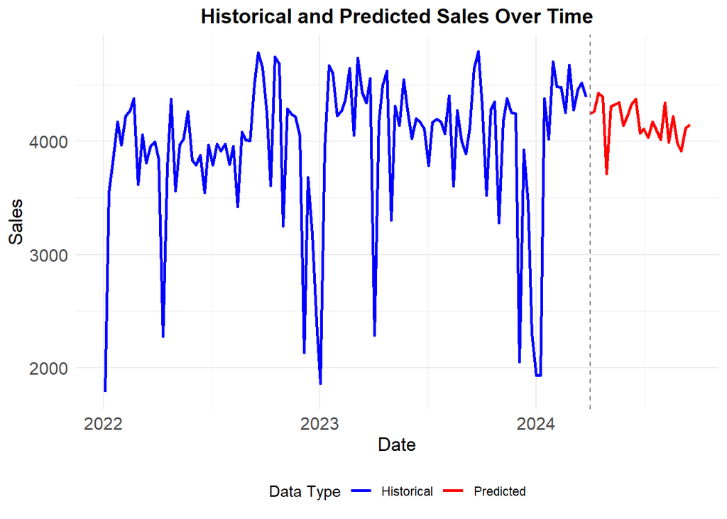

```r
# Create a data frame for combined visualization
train_plot_data <- data.frame(
  Monday_date = train_sales_data$Monday_date,
  Sales = train_sales_data$Sales,
  Type = "Historical"
)

test_plot_data <- data.frame(
  Monday_date = test_sales_data$Monday_date,
  Sales = test_sales_data$predicted_sales,
  Type = "Predicted"
)

combined_plot_data <- rbind(train_plot_data, test_plot_data)

# Create the combined time series plot
combined_plot <- ggplot(combined_plot_data, aes(x = Monday_date, y = Sales, color = Type)) +
  geom_line(linewidth = 1) +
  geom_vline(xintercept = as.numeric(min(test_sales_data$Monday_date)),
             linetype = "dashed", color = "gray50") +
  scale_color_manual(values = c("Historical" = "blue", "Predicted" = "red")) +
  labs(
    title = "Historical and Predicted Sales Over Time",
    x = "Date",
    y = "Sales",
    color = "Data Type"
  ) +
  theme_minimal() +
  theme(
    plot.title = element_text(hjust = 0.5, size = 14, face = "bold"),
    axis.text = element_text(size = 12),
    axis.title = element_text(size = 13),
    legend.position = "bottom"
  )

# Display the plot
print(combined_plot)
```

We notice the following:

- **Alignment with Trends**: Predicted sales (red line) generally follow the overall trends of actual sales (blue line), demonstrating that the model captures the major seasonal and periodic patterns in sales.
- **Stability in Predictions**: The predicted values show a smoother trajectory compared to the actual sales, suggesting that the model avoids overfitting but may underperform during sharp sales peaks or drops.

Finally, we save our results in **our submission file**:

```r
# Create and save the predictions file
predictions_df <- data.frame(
  Monday_date = format(test_sales_data$Monday_date, "%Y-%m-%d"),
  Sales = round(test_sales_data$predicted_sales, 0)  # Rounding to whole numbers
)

# Write to CSV
write.csv(predictions_df, file = "Juanro.csv", row.names = FALSE, quote = FALSE)

# Print first few rows of the saved predictions
cat("\nFirst few rows of saved predictions:\n")
```

```
##
## First few rows of saved predictions:
```

```r
head(predictions_df)
```

|  | Monday_date | Sales |
| --- | --- | --- |
| 1 | 2024-04-01 | 4244 |
| 2 | 2024-04-08 | 4266 |
| 3 | 2024-04-15 | 4428 |
| 4 | 2024-04-22 | 4392 |
| 5 | 2024-04-29 | 3714 |
| 6 | 2024-05-06 | 4308 |

# Final Analysis of Investment Variables and Predicted Sales

This section focuses on the interpretability of the model, particularly analyzing how **investment variables** affect the sales. The objective is to identify the key drivers of sales among the investment-related features, providing actionable insights for future strategies. We will base this analysis on:

- The **features selected by Elastic Net**,`elastic_grid`. Giving *only* these features to the other models consistently improved performance.
- The feature importance according to **the best-performing (individual) model** trained with all data, `xgb_grid_final`.

## Feature Selection (Elastic Net) and Interpretation

All the investment variables are:

```r
investment_vars
```

```
##  [1] "Affiliates_investment" "Meta_investment"       "sea_brand"
##  [4] "sea_other_investment"  "tiktok_investment"     "Database_investment"
##  [7] "OOH_investment"        "TV_hbtv_investment"    "TV_investment"
## [10] "Radio_investment"
```

Out of these, `elastic_grid` only chose the following:

```r
selected_features
```

```
##  [1] "log(Affiliates_investment + 1)"
##  [2] "log(Meta_investment + 1)"
##  [3] "log(sea_brand + 1)"
##  [4] "log(TV_hbtv_investment + 1)"
##  [5] "log(TV_investment + 1)"
##  [6] "log(GBP + 1)"
##  [7] "log(web_visits + 1)"
##  [8] "log(sea_brand_lag1 + 1)"
##  [9] "log(sea_brand_lag2 + 1)"
## [10] "log(sea_other_investment_lag2 + 1)"
## [11] "log(TV_hbtv_investment_lag1 + 1)"
## [12] "log(TV_hbtv_investment_lag2 + 1)"
## [13] "TV_hbtv_investment_is_zero"
## [14] "seasonal_semiannual_sin"
## [15] "seasonal_quarterly_cos"
## [16] "seasonal_monthly_sin"
## [17] "seasonal_monthly_cos"
## [18] "is_christmas_vacation"
## [19] "is_easter_vacation"
## [20] "log(TV_hbtv_investment + 1):Stores"
## [21] "log(TV_investment + 1):Stores"
## [22] "log(Meta_investment + 1):Stores"
## [23] "log(Affiliates_investment + 1):log(OOH_investment + 1)"
```

Investment channels selected and excluded:

- **All major TV-related investments were selected** (both traditional TV and HBTV), including their lagged effects and store interactions. This highlights their importance in determining sales.
- **Digital marketing channels were also included.** These include Meta, Affiliates, and Search Brand (`sea_brand`).
- **Radio, TikTok, and Database investments were excluded.** Therefore, these investments do not significantly impact sales, not even when considering interaction or lagged effects.

Important patterns:

- **There are strong temporal effects**: There were multiple lag terms selected for search brand (lag1, lag2) and TV HBTV (lag1, lag2).
- **Store interaction terms**: The store interactions were selected for TV, HBTV, and Meta investments, suggesting these channels’ effectiveness varies with store presence.
- **Channel synergies**: Specific interaction between Affiliates and OOH investment indicates complementarity between these two channels.

## Feature Importance (XGBoost) and Interpretation

We can **extract feature importance** according to the final XGBoost model with the following code snippet:

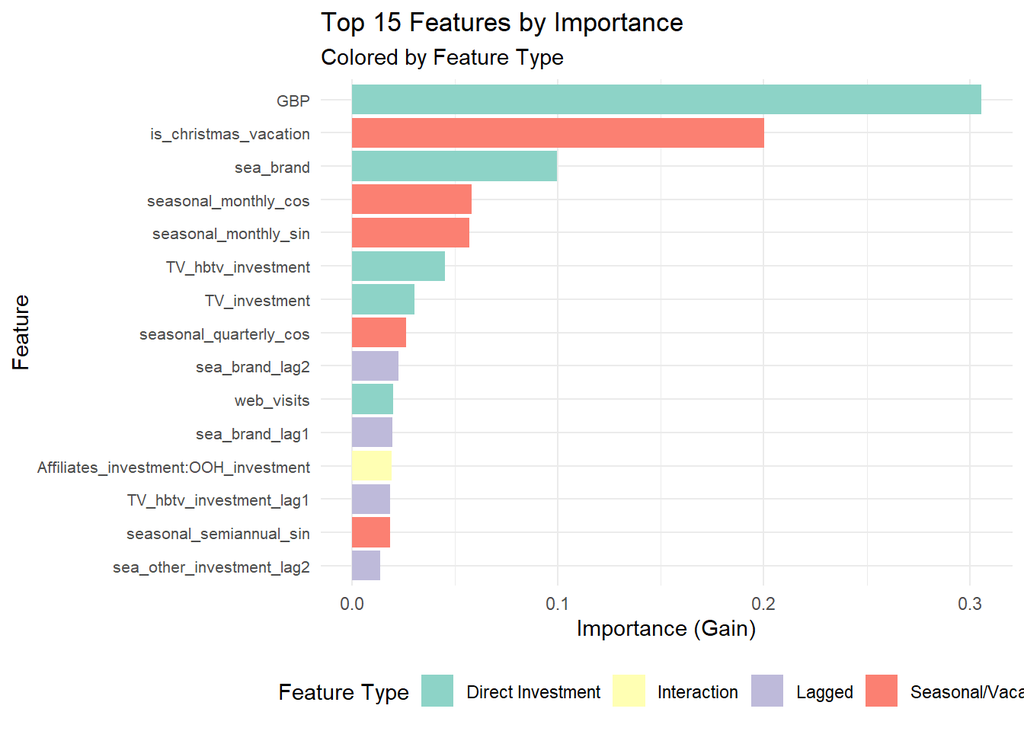

```r
# Extract feature importance using the exact feature names from the model
xgb_importance <- xgb.importance(
  feature_names = xgb_grid_final$finalModel$feature_names,
  model = xgb_grid_final$finalModel
)

# Filter for investment-related features and create analysis dataframe
investment_importance <- xgb_importance %>%
  mutate(
    is_elastic_net = Feature %in% selected_features,
    feature_type = case_when(
      grepl(":", Feature) ~ "Interaction",
      grepl("_lag", Feature) ~ "Lagged",
      grepl("_is_zero", Feature) ~ "Zero Indicator",
      grepl("seasonal|vacation", Feature) ~ "Seasonal/Vacation",
      TRUE ~ "Direct Investment"
    ),
    feature_category = case_when(
      grepl("TV", Feature) ~ "TV",
      grepl("Meta", Feature) ~ "Meta",
      grepl("sea_brand", Feature) ~ "Search Brand",
      grepl("Affiliates", Feature) ~ "Affiliates",
      grepl("OOH", Feature) ~ "OOH",
      TRUE ~ "Other"
    )
  ) %>%
  arrange(desc(Gain))

# Create feature importance plot
importance_plot <- ggplot(
  head(investment_importance, 15),
  aes(x = reorder(Feature, Gain), y = Gain, fill = feature_type)
) +
  geom_bar(stat = "identity") +
  coord_flip() +
  scale_fill_brewer(palette = "Set3") +
  labs(
    title = "Top 15 Features by Importance",
    subtitle = "Colored by Feature Type",
    x = "Feature",
    y = "Importance (Gain)",
    fill = "Feature Type"
  ) +
  theme_minimal() +
  theme(
    axis.text.y = element_text(size = 8),
    legend.position = "bottom"
  )

# Display the importance plot
print(importance_plot)
```

## Actionable Recommendations

Investment prioritization:

- Maintain **strong TV presence**.
- Continue **investment in Meta and brand Search Engine Advertising**.
- Consider **reducing or eliminating investment in unselected channels** (Radio, TikTok, Database).

Temporal strategy:

- Plan **Search Engine Advertising** with long-term effects in mind.
- Account for **1-2 week lag in campaign effectiveness** in this case.
- Adjust investment timing **around Christmas vacation period**.